fossil

# Gene dynamics from snapshots, dug back up.

The authors' code is gone, so we rebuilt the whole framework from the paper and its supplement and ran it again. Of 57 results, 2 came back exactly, 4 agree, 19 partly agree, 12 cannot be told apart, 14 differ and 6 are diagrams or 3D views we did not redraw.

See every result

## Fig. 2

Fig. 2D. Fit of the AND gate (green) and OR gate (red) FFL models to the gZ pseudo time series.

Differs

Published

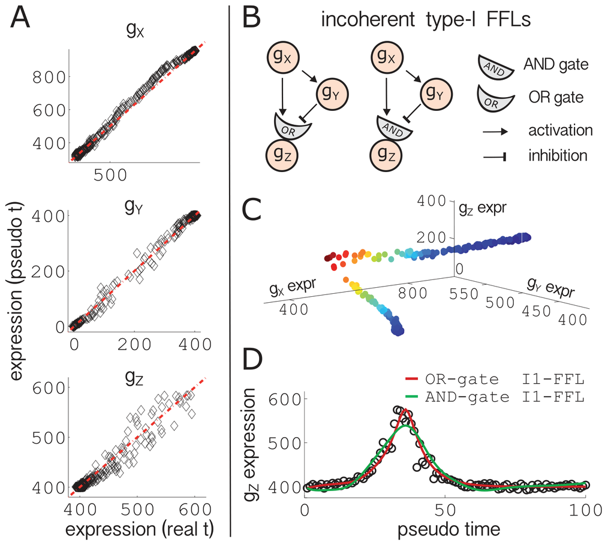

Our run

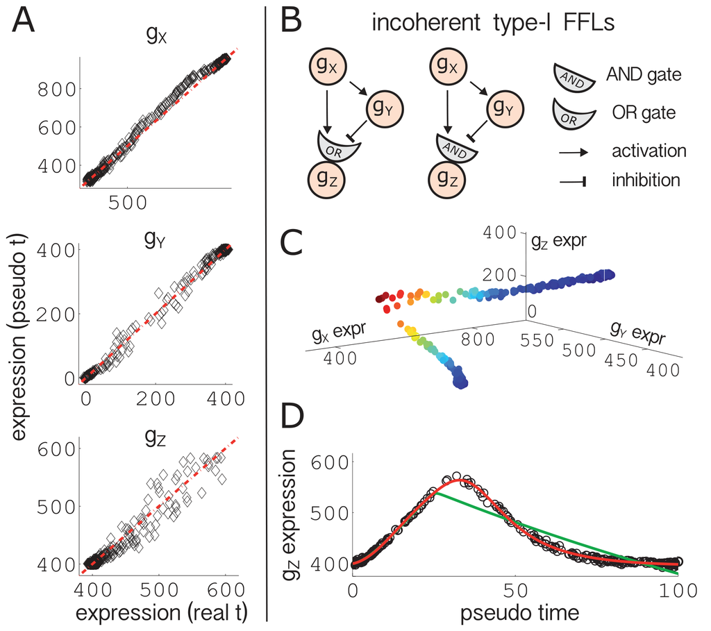

**Fig. 2D, OR gate fit (red)**

12.4% within 2 px, Inconclusive

**Fig. 2D, AND gate fit (green)**

5.7% within 2 px, Differs

Our cells are a new random draw and our Wanderlust ordering widens the gZ pulse, so the fitted curves lie off the published ones by more than 2 px over most of their length. As for the OR fit: a new draw of cells and a wider gZ pulse.

## Fig. 4

Fig. 4. Predictions of the inferred FFL (red) against noisy data from the perturbed true system (dots).

Inconclusive

Published

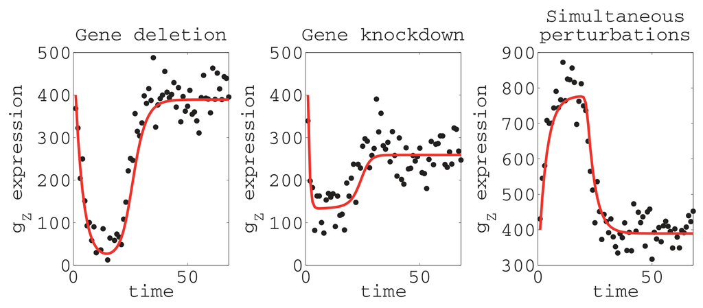

Our run

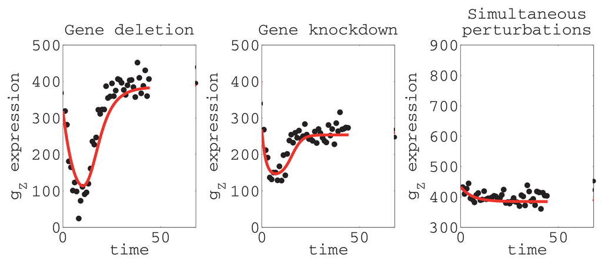

**Fig. 4, gY deletion**

15.6% within 2 px, Inconclusive

**Fig. 4, knockdown**

18.7% within 2 px, Inconclusive

**Fig. 4, simultaneous perturbations**

3.6% within 2 px, Inconclusive

Our time axis ends at T_f = 44 (the mean time for gX to pass 960), the published one at 68, and our estimated lambda is 0.17, so the predicted transients are slower and shorter. As for the deletion: a shorter time axis and a smaller estimated lambda. As for the deletion: a shorter time axis and a smaller estimated lambda, which blunts the fast peak.

## Fig. 5

Fig. 5, right. Pseudo time series of gA to gD along one toggle switch branch, coloured by pseudo time.

Inconclusive

Published

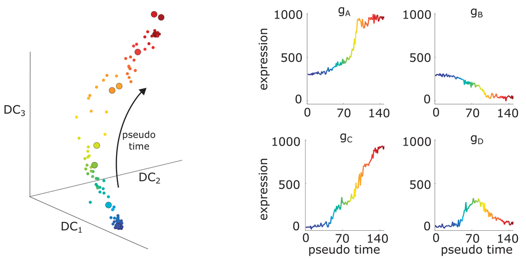

Our run

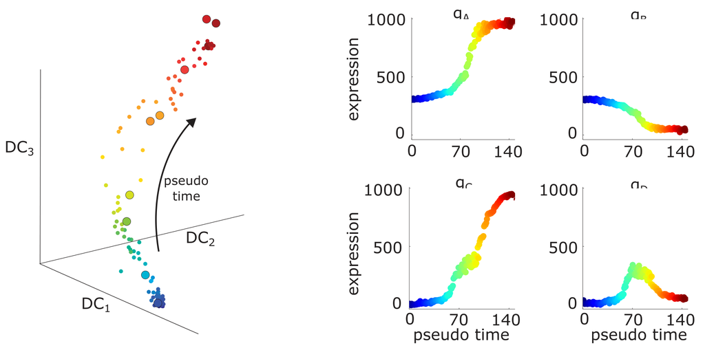

**Fig. 5, gA series**

48.4% within 2 px, Inconclusive

**Fig. 5, gB series**

55.5% within 2 px, Inconclusive

**Fig. 5, gC series**

46.7% within 2 px, Inconclusive

**Fig. 5, gD series**

54.6% within 2 px, Partly agrees

Our cells are another random draw, so our dots cannot fall on the published ones; the branch length (about 140 cells) and the shape of each series come back, but a 1.5 shift of pseudo time scores about as well as ours.

## Fig. 6

Fig. 6, right. The selected gC model (red) on the gC series of the two branches where gA is high.

Inconclusive

Published

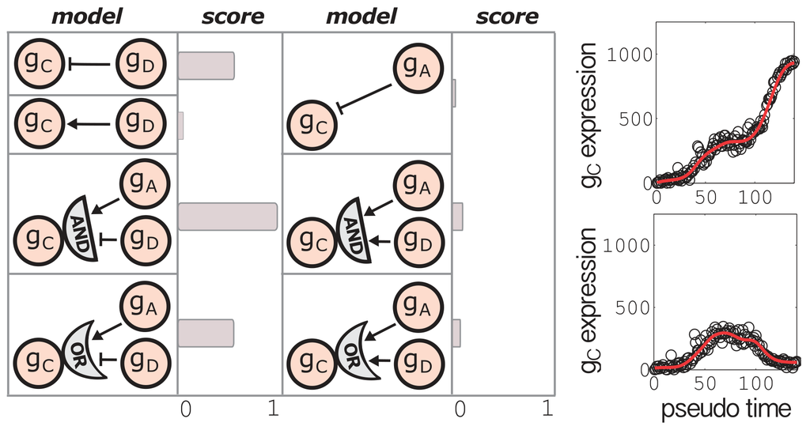

Our run

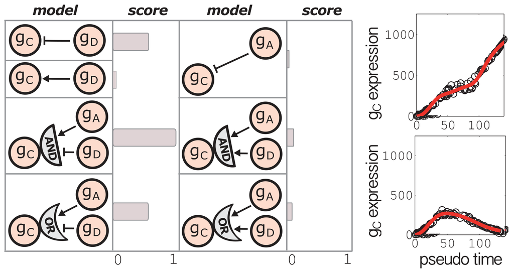

**Fig. 6, gC fit, branch C**

15.0% within 2 px, Inconclusive

**Fig. 6, gC fit, branch D**

18.3% within 2 px, Inconclusive

Our gC series is another random draw, drawn on the published axis by rank; the fitted curve rises earlier than the published one (see the curves in data units). As for the top panel: another draw, and a pulse at another pseudo time.

## Fig. 7

Fig. 7B. Diffusion map of the 597 haematopoietic cells, coloured by cell type. Our three components are projected onto the page by the linear map that best matches the cell-type centres.

Inconclusive

Published

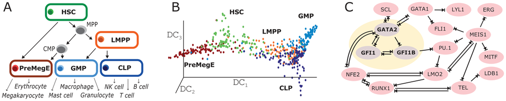

Our run

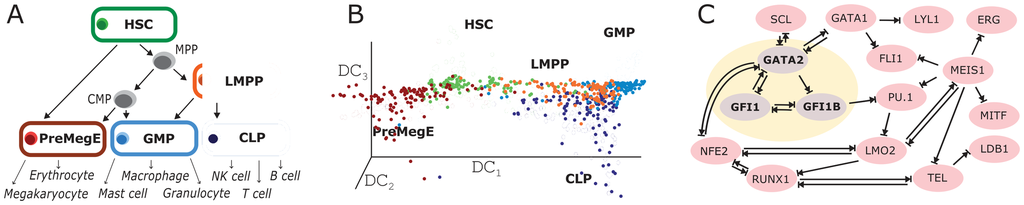

**Fig. 7B, diffusion map by cell type**

25.6% within 2 px, Inconclusive

The shape comes back (the four arms and the cell-type order), but the camera of the 3D view is fitted and our component order differs; doubling sigma scores as well, so the comparison cannot pin sigma down.

## Fig. 9

Fig. 9. Selected models (red) on the haematopoietic pseudo time series (circles): GATA2 on the CLP pathway, GFI1 and GFI1B on the GMP pathway.

Differs

Published

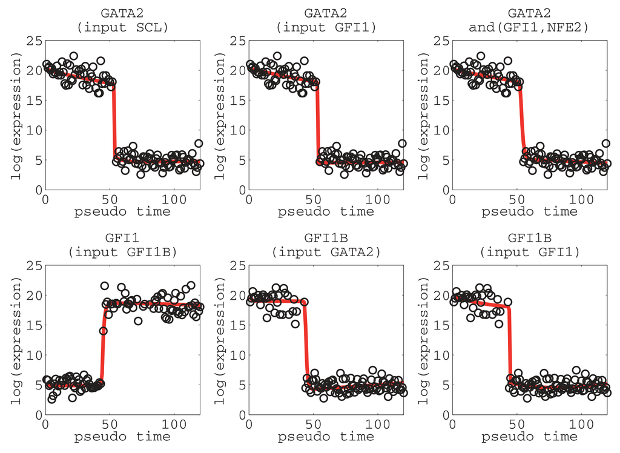

Our run

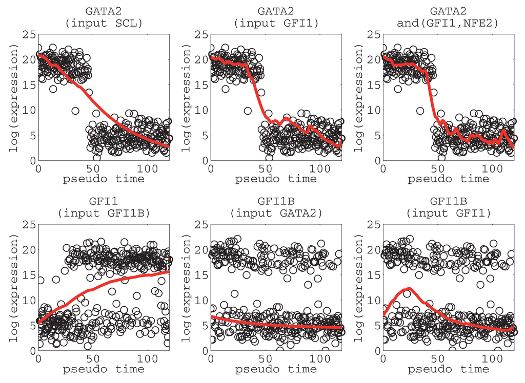

**Fig. 9, GATA2 with input SCL**

6.9% within 2 px, Inconclusive

**Fig. 9, GATA2 with input GFI1**

13.8% within 2 px, Inconclusive

**Fig. 9, GATA2 with AND(GFI1, NFE2)**

14.9% within 2 px, Partly agrees

**Fig. 9, GFI1 with input GFI1B**

3.1% within 2 px, Differs

**Fig. 9, GFI1B with input GATA2**

5.9% within 2 px, Differs

**Fig. 9, GFI1B with input GFI1**

5.8% within 2 px, Differs

Our series has three times as many cells and a different ordering, so the fitted step sits elsewhere and the curve lies off the published one.

## Every result

Every figure panel, table and number of the paper we compared, in the paper's order. Paper and ours are both shown; the verdict is computed from them.

Result

Verdict

Measure

Why

Fig. 1 (diagram)

Not attempted

A diagram of the framework. Its panels B to D and H reuse toggle switch results, scored in Fig. 1H, Figs 5 and 6 and supp. Fig. 6.

Fig. 1H, toggle switch posterior means

Partly agrees

1 of 6 values

- alpha posterior mean: paper 249.4, ours **356.5**
- lambda posterior mean: paper 0.2466, ours **0.34025**
- kp posterior mean: paper 414.57, ours **412.33**
- hp posterior mean: paper 16.05, ours **16.939**
- km posterior mean: paper 190.25, ours **178.691**
- hm posterior mean: paper 1.8065, ours **1.72301**

Our prior on lambda (SD 0.025) does not hold lambda at 0.25: its posterior mean is 0.34, and alpha (357) moves with it. kappa+ comes within 1% of Fig. 1H, the other three parameters within 7%.

Toggle switch: mean relative error about 6.8%

Differs

0 of 1 values

- mean relative error of the posterior means (%): paper 6.8, ours **20.3**

Our posterior means give 20.3%. With a prior ten times tighter the same fit gives 7.2%, so the paper's prior was most likely much tighter than ours; the paper does not give it.

Fig. 2A, gZ ordered worst

Agrees

2 of 2 values

- gZ further from the deterministic series than gX: paper yes, ours **yes**
- gZ further from the deterministic series than gY: paper yes, ours **yes**

Fig. 2B (FFL structures)

Not attempted

A schematic of the I1-FFL with AND and OR gates.

Fig. 2C, 3D snapshot

Not attempted

A 3D scatter of the 300 simulated cells; the camera of the view is not recoverable and the cells are a different random draw. The same cells are scored in Fig. 2A and 2D.

Fig. 2D, OR gate fit (red)

Inconclusive

12.4% within 2 px

Our cells are a new random draw and our Wanderlust ordering widens the gZ pulse, so the fitted curves lie off the published ones by more than 2 px over most of their length.

Fig. 2D, AND gate fit (green)

Differs

5.7% within 2 px

As for the OR fit: a new draw of cells and a wider gZ pulse.

Supp. Fig. 13, FFL GENIE3 weights and correlations

Partly agrees

3 of 7 values

- GENIE3 weight gX->gY: paper 0.96, ours **0.933**
- GENIE3 weight gY->gX: paper 0.83, ours **0.819**
- GENIE3 weight gX->gZ: paper 0.45, ours **0.491**
- GENIE3 weight gY->gZ: paper 0.55, ours **0.509**
- r(gX, gY): paper 0.9, ours **0.91**
- r(gX, gZ): paper -0.4, ours **-0.39**
- r(gY, gZ): paper -0.2, ours **-0.16**

The weights and correlations come from another random draw of 300 cells; GENIE3's weights also depend on its settings.

Supp. Fig. 14, AIC and BIC of the 12 FFL models

Partly agrees

2 of 15 values

- best model by AIC: paper or(gX+,gY-), ours **or(gX+,gY-)**
- second model by AIC: paper or(gX-,gY+), ours **or(gX-,gY+)**
- third model by AIC: paper and(gX+,gY-), ours **or(gX-,gY-)**
- AIC or(gX+,gY-): paper -407, ours **-2290**
- AIC or(gX-,gY+): paper -417, ours **-2296**
- AIC and(gX+,gY-): paper -457, ours **-14005**
- AIC or(gX-,gY-): paper -810, ours **-12123**
- AIC gY-: paper -816, ours **-15262**
- AIC and(gX-,gY-): paper -819, ours **-15264**
- AIC and(gX-,gY+): paper -821, ours **-24594**
- AIC gX-: paper -949, ours **-17228**
- AIC gY+: paper -1365, ours **-94359**
- AIC or(gX+,gY+): paper -1367, ours **-93736**
- AIC and(gX+,gY+): paper -1368, ours **-94361**
- AIC gX+: paper -1371, ours **-93739**

The AIC and BIC values scale with the number of observations and the likelihood SD, neither of which the paper gives (its BIC minus AIC implies about 100 to 150 observations; we fit 900). The ranking is the comparison that counts.

FFL: Bayes factors above 100

Partly agrees

2 of 4 values

- R(OR/AND) > 100: paper yes, ours **yes**
- R(OR, gX+ gY- / OR, gX- gY+) > 100: paper yes, ours **yes**
- log p(D|M) of OR, gX+ gY-: paper -385, ours **-2331**
- log p(D|M) of OR, gX- gY+: paper -400, ours **-2338**

Both Bayes factors exceed 100 as in the paper; the log evidences themselves scale with the number of observations and the likelihood SD, which the paper does not give.

FFL: mean relative error about 17%

Differs

0 of 1 values

- mean relative error of the MAP estimates (%): paper 17, ours **28.1**

Our MAP estimates put alpha and lambda about 35% low with their ratio near the truth, as the paper reports for Fig. 3; the Hill coefficients come out lower than the paper's, which moves the mean error.

FFL: 14.5% with an informative prior

Differs

0 of 1 values

- mean relative error with an informative prior on lambda (%): paper 14.5, ours **28**

Our informative prior (SD 0.025) does not move lambda against 900 observations; the paper's lambda of 0.249 implies a much tighter prior or fewer observations.

FFL: alpha/lambda exactly 400

Differs

0 of 1 values

- posterior median of alpha / lambda: paper 400, ours **387**

Our ratio comes back 3% below 400, not exactly 400.

Fig. 3, FFL posterior modes

Partly agrees

1 of 7 values

- alpha posterior mode: paper 62.9, ours **63.66**
- lambda posterior mode: paper 0.1575, ours **0.16437**
- kp posterior mode: paper 412.05, ours **402.885**
- hp posterior mode: paper 16.38, ours **10.091**
- km posterior mode: paper 245.2, ours **235.21**
- hm posterior mode: paper 12.08, ours **6.973**
- alpha / lambda: paper 399, ours **387.4**

alpha, lambda, kappa+ and kappa- come back within 5% of the paper's modes (alpha 63.7 against 62.9, lambda 0.164 against 0.1575); the Hill coefficients do not (h+ 10.1 against 16.4, h- 7.0 against 12.1). The posteriors are narrow, so the 2% tolerance tests the point estimates.

Supp. Table 4, FFL parameter modes

Partly agrees

1 of 10 values

- gZ alpha: paper 96.9701, ours **64.7775**
- gZ lambda: paper 0.2490, ours **0.16748**
- gZ kp: paper 417.1350, ours **403.2**
- gZ hp: paper 14.1570, ours **10.0933**
- gZ km: paper 264.2697, ours **236.123**
- gZ hm: paper 8.1481, ours **6.88862**
- gY alpha: paper 99.1890, ours **87.9813**
- gY lambda: paper 0.2489, ours **0.21954**
- gY kp: paper 420.0862, ours **415.873**
- gY hp: paper 14.7256, ours **11.8015**

Table 4's gZ values need lambda near 0.249, which our prior does not reach (see the informative-prior item).

Fig. 4, gY deletion

Inconclusive

15.6% within 2 px

Our time axis ends at T_f = 44 (the mean time for gX to pass 960), the published one at 68, and our estimated lambda is 0.17, so the predicted transients are slower and shorter.

Fig. 4, knockdown

Inconclusive

18.7% within 2 px

As for the deletion: a shorter time axis and a smaller estimated lambda.

Fig. 4, simultaneous perturbations

Inconclusive

3.6% within 2 px

As for the deletion: a shorter time axis and a smaller estimated lambda, which blunts the fast peak.

FFL: predictions fit the perturbed system

Partly agrees

1 of 3 values

- prediction fits the perturbed system (deletion; R^2 >= 0.8): paper yes, ours **yes**
- prediction fits the perturbed system (knockdown; R^2 >= 0.8): paper yes, ours **no**
- prediction fits the perturbed system (simultaneous; R^2 >= 0.8): paper yes, ours **no**

The deletion prediction fits (R^2 above 0.8); the knockdown and the simultaneous perturbation do not, because our lambda (0.17) slows the fast transients.

Supp. Fig. 6, four significant eigenvalues

Agrees

1 of 1 values

- significant diffusion-map eigenvalues: paper 4, ours **4**

Fig. 5, left (3D branch)

Not attempted

A 3D view of one diffusion map branch coloured by pseudo time; the camera is not recoverable. The branch's series are scored in Fig. 5, right.

Fig. 5, gA series

Inconclusive

48.4% within 2 px

Our cells are another random draw, so our dots cannot fall on the published ones; the branch length (about 140 cells) and the shape of each series come back, but a 1.5 shift of pseudo time scores about as well as ours.

Fig. 5, gB series

Inconclusive

55.5% within 2 px

Our cells are another random draw, so our dots cannot fall on the published ones; the branch length (about 140 cells) and the shape of each series come back, but a 1.5 shift of pseudo time scores about as well as ours.

Fig. 5, gC series

Inconclusive

46.7% within 2 px

Our cells are another random draw, so our dots cannot fall on the published ones; the branch length (about 140 cells) and the shape of each series come back, but a 1.5 shift of pseudo time scores about as well as ours.

Fig. 5, gD series

Partly agrees

54.6% within 2 px

Our cells are another random draw, so our dots cannot fall on the published ones; the branch length (about 140 cells) and the shape of each series come back, but a 1.5 shift of pseudo time scores about as well as ours.

Fig. 5, series medians in data units

Partly agrees

17 of 28 values

- gA median, pseudo time 0 to 20: paper 310, ours **309.8**
- gA median, pseudo time 20 to 40: paper 322, ours **332.1**
- gA median, pseudo time 40 to 60: paper 386, ours **367.1**
- gA median, pseudo time 60 to 80: paper 444, ours **488.2**
- gA median, pseudo time 80 to 100: paper 694, ours **806.8**
- gA median, pseudo time 100 to 120: paper 896, ours **934.3**
- gA median, pseudo time 120 to 140: paper 953, ours **956.6**
- gB median, pseudo time 0 to 20: paper 294, ours **303.4**
- gB median, pseudo time 20 to 40: paper 281, ours **284.3**
- gB median, pseudo time 40 to 60: paper 230, ours **255.6**
- gB median, pseudo time 60 to 80: paper 189, ours **191.9**
- gB median, pseudo time 80 to 100: paper 106, ours **86.7**
- gB median, pseudo time 100 to 120: paper 45, ours **48.5**
- gB median, pseudo time 120 to 140: paper 33, ours **45.3**
- gC median, pseudo time 0 to 20: paper 1, ours **8.5**
- gC median, pseudo time 20 to 40: paper 21, ours **21.2**
- gC median, pseudo time 40 to 60: paper 113, ours **72**
- gC median, pseudo time 60 to 80: paper 269, ours **284.6**
- gC median, pseudo time 80 to 100: paper 392, ours **395.7**
- gC median, pseudo time 100 to 120: paper 605, ours **722.6**
- gC median, pseudo time 120 to 140: paper 869, ours **906.7**
- gD median, pseudo time 0 to 20: paper 5, ours **11.7**
- gD median, pseudo time 20 to 40: paper 21, ours **18**
- gD median, pseudo time 40 to 60: paper 100, ours **72**
- gD median, pseudo time 60 to 80: paper 281, ours **268.8**
- gD median, pseudo time 80 to 100: paper 243, ours **243.4**
- gD median, pseudo time 100 to 120: paper 123, ours **103.7**
- gD median, pseudo time 120 to 140: paper 62, ours **59.3**

Fig. 6, model scores for gC

Partly agrees

4 of 8 values

- best model: paper and(A+,D-), ours **and(A+,D-)**
- score D-: paper 0.57, ours **0.833**
- score D+: paper 0.05, ours **0.006**
- score A-: paper 0.03, ours **0**
- score and(A+,D-): paper 1.00, ours **1**
- score and(A+,D+): paper 0.10, ours **0.007**
- score or(A+,D-): paper 0.56, ours **0.833**
- score or(A+,D+): paper 0.08, ours **0.007**

AND(gA+, gD-) is best, as in the paper. The other scores differ: gD alone and the OR gate score 0.83 against the paper's 0.57 and 0.56, probably because their AIC gap to the best model is relatively smaller in our 837 observations.

Supp. Fig. 18 and text: the same for gD

Agrees

2 of 2 values

- best model for gD: paper and(A+,C-), ours **and(A+,C-)**
- every other model at least 400 AIC units behind (paper: -589 against below -1000): paper yes, ours **yes**

Supp. 1.3: Wanderlust in low and high dimension, 92%

Partly agrees

1 of 2 values

- correlation of pseudo times, high against low dimension (%): paper 92, ours **99.2**
- low- and high-dimensional pseudo times very similar, as the paper concludes from 92% (correlation of 90% or more): paper yes, ours **yes**

Our pseudo times on the data and on four diffusion components correlate at 99.2%, closer than the paper's 92%; the paper's conclusion, that the two are very similar, holds. The paper does not say how its correlation is computed or which replicates it pairs.

Supp. 2.2.3, 2.2.4 and 2.2.7: further robustness runs

Not attempted

Not attempted. The runs with noise 200 and 300, Nn from 5 to 30, forward and backward start cells, three sampling functions and 200 cells rest on start cells picked by eye (supp. Fig. 22) and on sampling functions shown only as plots (supp. Fig. 26).

Fig. 6, gC fit, branch C

Inconclusive

15.0% within 2 px

Our gC series is another random draw, drawn on the published axis by rank; the fitted curve rises earlier than the published one (see the curves in data units).

Fig. 6, gC fit, branch D

Inconclusive

18.3% within 2 px

As for the top panel: another draw, and a pulse at another pseudo time.

Fig. 6, gC fits in data units

Partly agrees

4 of 16 values

- branch C, fit at pseudo time 20: paper 30, ours **104.1**
- branch C, fit at pseudo time 40: paper 147, ours **253.4**
- branch C, fit at pseudo time 60: paper 274, ours **307.9**
- branch C, fit at pseudo time 80: paper 327, ours **365.1**
- branch C, fit at pseudo time 100: paper 375, ours **496.8**
- branch C, fit at pseudo time 120: paper 756, ours **744.5**
- branch C, maximum of the fit: paper 946, ours **930.3**
- branch C, pseudo time of the maximum: paper 138.4, ours **145.1**
- branch D, fit at pseudo time 20: paper 21, ours **118.3**
- branch D, fit at pseudo time 40: paper 98, ours **255.9**
- branch D, fit at pseudo time 60: paper 272, ours **257.4**
- branch D, fit at pseudo time 80: paper 252, ours **206.5**
- branch D, fit at pseudo time 100: paper 234, ours **131.2**
- branch D, fit at pseudo time 120: paper 72, ours **70.5**
- branch D, maximum of the fit: paper 309, ours **268.6**
- branch D, pseudo time of the maximum: paper 67.8, ours **49.2**

Supp. Table 6, errors under observation noise

Differs

0 of 5 values

- none: paper 6.8, ours **13.9**
- add20: paper 7.6, ours **6.9**
- add40: paper 9.1, ours **13.5**
- mul0.04: paper 5.1, ours **7.8**
- mul0.12: paper 8.2, ours **37.8**

Our errors under observation noise scatter from 6.9 to 37.8% around the paper's 5.1 to 9.1%, with the same weak prior as our main fit.

Supp. Table 1, clustering errors

Partly agrees

2 of 6 values

- low-dimensional, sigma 20: paper 7.4, ours **17.2**
- high-dimensional, sigma 20: paper 9.9, ours **22.1**
- low-dimensional, sigma 80: paper 8.7, ours **20.6**
- high-dimensional, sigma 80: paper 14.1, ours **26.2**
- low beats high at sigma 20: paper yes, ours **yes**
- low beats high at sigma 80: paper yes, ours **yes**

Low-dimensional clustering beats high-dimensional clustering at both noise levels, as in the paper, but our errors are about twice the paper's. The start and end cells were picked by eye in the paper, and its six regions are defined by plots we cannot read exactly.

Supp. Figs 17 and 25, inputs of gC

Partly agrees

3 of 4 values

- inputs of gC at w >= 0.3: paper A,D, ours **A,D**
- sign of gA on gC: paper +, ours **+**
- sign of gD on gC: paper -, ours **?**
- inputs of gC at w >= 0.1: paper A,B,D, ours **A,B,D**

GENIE3 on our draw keeps the inputs of supp. Figs 17 and 25 only in part; the weights depend on the draw and on GENIE3's settings.

Supp. Table 7, 94 gC models

Partly agrees

1 of 6 values

- best model by BIC: paper and(A+,D-), ours **and(or(A+,B-),D-)**
- best model by AIC: paper and(or(A+,B-),D-), ours **and(or(A+,B-),D-)**
- log p(D|M) of and(A+,D-): paper -566.195, ours **-3601.32**
- log p(D|M) of and(or(A+,B-),D-): paper -567.455, ours **-3540.6**
- Bayes factor: paper 3.53, ours **0**
- Bayes factor favours and(A+,D-): paper yes, ours **no**

and(or(gA+, gB-), gD-) wins on BIC, AIC and the Bayes factor in our run; the paper's BIC and Bayes factor favour and(gA+, gD-). gB does not collapse out of our fit.

597 cells after quality control

Exact

6 of 6 values

- cells after quality control: paper 597, ours **597**
- CLP cells: paper 123, ours **123**
- GMP cells: paper 124, ours **124**
- HSC cells: paper 121, ours **121**
- LMPP cells: paper 116, ours **116**
- PreMegE cells: paper 113, ours **113**

Fig. 7A (lineage diagram)

Not attempted

A schematic of the haematopoietic lineages.

Supp. Fig. 32A, maximum of <d>

Exact

1 of 1 values

- log10 sigma at the maximum of <d>: paper 0.9, ours **0.9**

Fig. 7B, diffusion map by cell type

Inconclusive

25.6% within 2 px

The shape comes back (the four arms and the cell-type order), but the camera of the 3D view is fitted and our component order differs; doubling sigma scores as well, so the comparison cannot pin sigma down.

Fig. 7C, GENIE3 network (w > 0.08)

Partly agrees

28 of 31 values

- SCL -> GATA2: paper yes, ours **yes**
- GATA2 -> SCL: paper yes, ours **yes**
- GATA1 -> GATA2: paper yes, ours **yes**
- GATA2 -> GATA1: paper yes, ours **yes**
- GATA1 -> LYL1: paper yes, ours **yes**
- GATA1 -> FLI1: paper yes, ours **yes**
- MEIS1 -> FLI1: paper yes, ours **yes**
- MEIS1 -> ERG: paper yes, ours **yes**
- MEIS1 -> PU.1: paper yes, ours **yes**
- MEIS1 -> MITF: paper yes, ours **yes**
- MEIS1 -> LMO2: paper yes, ours **yes**
- LMO2 -> MEIS1: paper yes, ours **yes**
- MEIS1 -> TEL: paper yes, ours **yes**
- TEL -> LDB1: paper yes, ours **no**
- GATA2 -> GFI1: paper yes, ours **yes**
- GFI1 -> GATA2: paper yes, ours **yes**
- GATA2 -> GFI1B: paper yes, ours **yes**
- GFI1 -> GFI1B: paper yes, ours **yes**
- GFI1B -> GFI1: paper yes, ours **yes**
- GFI1B -> PU.1: paper yes, ours **yes**
- PU.1 -> LMO2: paper yes, ours **no**
- GATA2 -> NFE2: paper yes, ours **yes**
- NFE2 -> GATA2: paper yes, ours **yes**
- NFE2 -> LMO2: paper yes, ours **yes**
- LMO2 -> NFE2: paper yes, ours **yes**
- NFE2 -> RUNX1: paper yes, ours **yes**
- RUNX1 -> NFE2: paper yes, ours **yes**
- LMO2 -> RUNX1: paper yes, ours **yes**
- RUNX1 -> TEL: paper yes, ours **yes**
- TEL -> RUNX1: paper yes, ours **yes**
- edges with w > 0.08: paper 30, ours **29**

28 of the 30 published edges come back and one edge is extra. All three differences lie within 0.002 of the 0.08 threshold: PU.1 to LMO2 0.0799, TEL to LDB1 0.0782, GFI1B to GATA2 0.0807. Which side of the threshold they fall on depends on the random trees.

Supp. Fig. 29, six correlations

Partly agrees

5 of 6 values

- r(GATA1,GATA2): paper 0.42, ours **0.415**
- r(SCL,GATA2): paper 0.47, ours **0.4688**
- r(NFE2,GATA2): paper 0.51, ours **0.5141**
- r(GFI1,GATA2): paper -0.48, ours **-0.4752**
- r(GFI1B,GATA2): paper 0.44, ours **0.4382**
- r(GFI1,GFI1B): paper -0.40, ours **-0.4056**

Five of the six correlations come back at the printed precision; r(GFI1, GFI1B) is -0.4056 against -0.40.

Supp. 2.3.1, branch clustering errors

Differs

0 of 3 values

- PreMegE branch error (%): paper 1.3, ours **6.74**
- GMP branch error (%): paper 7.4, ours **31.25**
- CLP branch error (%): paper 10.3, ours **1.04**

The paper picked the start and end cells by eye; ours are the tips of the embedding. Our GMP branch takes in 55 cells of other pathways (54 CLP, 1 PreMegE) of its 176.

Supp. Table 8, GATA2 models (CLP)

Differs

0 of 20 values

- best GATA2 model by AIC: paper and(NFE2,SCL), ours **and(GFI1,NFE2)**
- worst GATA2 model by AIC: paper NFE2, ours **SCL**
- effective inputs of the best model: paper SCL+, ours **GFI1-,NFE2+**
- AIC and(NFE2,SCL): paper -210, ours **-2836**
- AIC or(NFE2,SCL): paper -210, ours **-2901**
- AIC and(GFI1,NFE2): paper -211, ours **-2737**
- AIC or(GFI1,NFE2): paper -211, ours **-2809**
- AIC or(GFI1,SCL): paper -211, ours **-2990**
- AIC and(or(GFI1,NFE2),SCL): paper -212, ours **-2811**
- AIC and(or(GFI1,SCL),NFE2): paper -212, ours **-2741**
- AIC and(or(NFE2,SCL),GFI1): paper -212, ours **-2739**
- AIC or(and(GFI1,SCL),NFE2): paper -213, ours **-2839**
- AIC or(and(NFE2,SCL),GFI1): paper -213, ours **-2772**
- AIC or(GFI1,NFE2,SCL): paper -213, ours **-2811**
- AIC GFI1: paper -214, ours **-3072**
- AIC or(and(GFI1,NFE2),SCL): paper -215, ours **-2836**
- AIC and(GFI1,NFE2,SCL): paper -217, ours **-2739**
- AIC SCL: paper -223, ours **-3280**
- AIC and(GFI1,SCL): paper -228, ours **-3000**
- AIC NFE2: paper -302, ours **-2834**

Our AIC values scale with our 958 observations (3 replicates of about 360 cells, after outlier removal) against the paper's about 115 points per series. Our best GATA2 model is and(GFI1, NFE2), the paper's new prediction, but SCL alone ranks last.

Supp. Table 9, GFI1 models (GMP)

Differs

0 of 6 values

- best GFI1 model by AIC: paper or(GATA2,GFI1B), ours **GATA2**
- worst GFI1 model by AIC: paper GATA2, ours **GFI1B**
- AIC or(GATA2,GFI1B): paper -191, ours **-3438**
- AIC GFI1B: paper -193, ours **-3441**
- AIC and(GATA2,GFI1B): paper -198, ours **-3426**
- AIC GATA2: paper -213, ours **-3424**

Our best GFI1 model is GATA2 alone, which the paper ranks worst; our GMP ordering does not give GFI1 the clean low-to-high switch of supp. Fig. 28.

Supp. Table 9, GFI1B models (GMP)

Differs

0 of 6 values

- best GFI1B model by AIC: paper GATA2, ours **or(GATA2,GFI1)**
- worst GFI1B model by AIC: paper and(GATA2,GFI1), ours **GATA2**
- AIC GATA2: paper -212, ours **-3685**
- AIC or(GATA2,GFI1): paper -216, ours **-3464**
- AIC GFI1: paper -219, ours **-3520**
- AIC and(GATA2,GFI1): paper -220, ours **-3522**

Our best GFI1B model is or(GATA2, GFI1), with only GFI1 effective; the paper finds GATA2 and GFI1 each on their own.

Fig. 8, refined subnetwork

Partly agrees

3 of 7 values

- SCL activates GATA2 (CLP): paper yes, ours **no**
- GFI1 inhibits GATA2 (CLP): paper yes, ours **yes**
- AND(GFI1, NFE2) on GATA2 (CLP): paper yes, ours **yes**
- GFI1B inhibits GFI1 (GMP): paper yes, ours **no**
- GATA2 regulates GFI1 (GMP): paper no, ours **yes**
- GFI1 inhibits GFI1B (GMP): paper yes, ours **yes**
- GATA2 activates GFI1B (GMP): paper yes, ours **no**

GFI1 inhibiting GATA2, AND(GFI1, NFE2) on GATA2 and GFI1 inhibiting GFI1B come back; the SCL edge, the GFI1B edge on GFI1 and the GATA2 edge on GFI1B do not.

Fig. 9, GATA2 with input SCL

Inconclusive

6.9% within 2 px

Our series has three times as many cells and a different ordering, so the fitted step sits elsewhere and the curve lies off the published one.

Fig. 9, GATA2 with input GFI1

Inconclusive

13.8% within 2 px

Our series has three times as many cells and a different ordering, so the fitted step sits elsewhere and the curve lies off the published one.

Fig. 9, GATA2 with AND(GFI1, NFE2)

Partly agrees

14.9% within 2 px

Our series has three times as many cells and a different ordering, so the fitted step sits elsewhere and the curve lies off the published one.

Fig. 9, GFI1 with input GFI1B

Differs

3.1% within 2 px

Our series has three times as many cells and a different ordering, so the fitted step sits elsewhere and the curve lies off the published one.

Fig. 9, GFI1B with input GATA2

Differs

5.9% within 2 px

Our series has three times as many cells and a different ordering, so the fitted step sits elsewhere and the curve lies off the published one.

Fig. 9, GFI1B with input GFI1

Differs

5.8% within 2 px

Our series has three times as many cells and a different ordering, so the fitted step sits elsewhere and the curve lies off the published one.

Fig. 9, points per series

Differs

0 of 3 values

- points in GATA2_SCL: paper 115, ours **304**
- points in GFI1_GFI1B: paper 102, ours **361**
- points in GFI1B_GATA2: paper 109, ours **361**

The published series have 102 to 115 points; ours keep all cells of a pathway except the outliers removed (304 of 360 for GATA2 on CLP).

Claims recomputed from the paper's own numbers

Agrees

4 of 7 values

- 14.5% from supp. Table 4 (gZ): paper 14.5, ours **14.6**
- 17% from the modes of Fig. 3: paper 17, ours **23.1**
- 6.8% from the posteriors of Fig. 1H: paper 6.8, ours **6.59**
- R > 100 from log p(D|M) = -385 and -400: paper yes, ours **yes**
- Bayes factor 3.53 from log p(D|M) of supp. Table 7: paper 3.53, ours **3.5254**
- Fig. 6 best model has score 1: paper and(A+,D-), ours **and(A+,D-)**
- AIC/BIC of supp. Fig. 14: best model is the OR gate gX+ gY-: paper or(gX+,gY-), ours **or(gX+,gY-)**

The paper's main claim holds on the simulated data: the OR gate wins for the feed-forward loop, and AND(gA+, gD-) wins for gC among Fig. 6's seven models (among supp. Table 7's 94, a model with gB wins). The parameter errors do not come back, and the refined network of Fig. 8 comes back only in part (3 of 7 edges); the causes are the unstated informative prior, pseudo time scale and noise settings, and the unstated choice of cells and orderings on the GMP and CLP pathways.

## What came back

**The cells**

Moignard's quality control on their Supplementary Table 3 leaves exactly the paper's 597 cells and its five per-type counts.

**The kernel width**

Supplementary Table 10 prints 100.9 for the qPCR data. Its Figure 32A puts the best width at 10 to the power 0.9, and so does our curve. 100.9 flattens the map.

**The network**

GENIE3 with extra-trees gives 29 edges above 0.08, and 28 of them are the 30 of Fig. 7C.

**The noise**

The supplement's own traces give the system noise: 2 for the feed-forward loop and about 6 for the toggle switch.

**The feed-forward loop logic**

AIC and thermodynamic integration pick the OR gate with gX activating and gY repressing, by Bayes factors far above 100.

**Fig. 3's odd rates**

Our MAP estimates put alpha near 64 and lambda near 0.16, as Fig. 3 does: both about 35% below the truth.

**The toggle switch map**

Four eigenvalues stand out and the cells form an X with four branches, as in supp. Fig. 6 and Fig. 1B.

## What stayed buried

- The authors' C++ and Matlab code
- Which cells make the paper's haematopoietic pseudo time series (102 to 115 points, against about 360 cells per pathway)
- The likelihood variance, the chain lengths, the temperature ladder and the informative prior's width
- The start and end cells the authors picked by eye
- The camera of the 3D views in Figs 2C and 5

The paper's main claim holds on the simulated data: the OR gate wins for the feed-forward loop, and AND(gA+, gD-) wins for gC among Fig. 6's seven models (among supp. Table 7's 94, a model with gB wins). The parameter errors do not come back, and the refined network of Fig. 8 comes back only in part (3 of 7 edges); the causes are the unstated informative prior, pseudo time scale and noise settings, and the unstated choice of cells and orderings on the GMP and CLP pathways.

## What we matched

The paper's figures are vector drawings. We read each panel's axes from its tick labels in the PDF and draw our curves on the same pixel grid at 600 dpi, in the published colours. A score is the share of the published line within 2 px of ours, and of ours within 2 px of the published line; the smaller counts.

**Our run**

The two simulated systems, rerun from their equations with noise read from the supplement's traces, and the Moignard 2013 qPCR data. Diffusion maps, Wanderlust, GENIE3, the ODE models, MCMC and thermodynamic integration rebuilt in Python.

**Axes**

One linear map per axis from the tick labels of the vector figure; the plotted curves and points read out of the same PDF give the paper's numbers where it prints none.

**Fitted, not data**

The view of Fig. 7B (a linear projection of our three components that sends each cell type's centre to the published one) and GENIE3's tree method (from a grid of four).

**Controls**

Each panel is also scored with a wrong input (another panel's curve) and near misses (a 1% shift, amplitude x 1.05). A panel agrees only when ours beats them and passes 90%.

**Reading the views**

On this page the overlay is drawn in the browser: ink is the paper only, light green is ours only, dark green is both. Difference: darker means a larger grey-level difference. The overlay PNGs in the repository use red for the paper and cyan for ours.